**Alejandro Tuy Fajardo**

**Red neuronal convolucional para la clasificación radiografías de tórax afectados con covid-19, neumonía viral o sanos**

# **Importación de librerías**

```python
#Instalo las librerías necesarias
!pip install visualkeras
!pip install ann_visualizer
!pip install graphviz
```

```
     ━━━━━━━━━━━━━━━━━━━━━━━━━━━━━━━━━━━━━━ 992.2/992.2 KB 13.8 MB/s eta 0:00:00
  Preparing metadata (setup.py) ... done
```

```python
# Importación de librerías

import os
import pathlib
import numpy as np
import pandas as pd
from matplotlib import pyplot
import matplotlib.image as mpimg
import random
import cv2
from sklearn.model_selection import train_test_split
from sklearn.metrics import ConfusionMatrixDisplay
from keras.models import Sequential
from keras.models import Model
from keras.layers import Dense, Activation, Conv2D, MaxPool2D, Flatten, Dropout, BatchNormalization
from keras.callbacks import EarlyStopping
import tensorflow as tf
from google.colab import files
from sklearn.metrics import classification_report,confusion_matrix, accuracy_score
import time
from skimage import data, io
from skimage.color import rgb2gray
import matplotlib.pyplot as plt
%matplotlib inline
import os
os.environ['TF_CPP_MIN_LOG_LEVEL'] = '3'
import warnings
# Suppress warnings
warnings.filterwarnings('ignore')
from IPython.display import display
from keras import utils
from keras.models import Sequential,load_model
from keras.optimizers import Adam
import keras
from keras import layers
import seaborn as sns
import visualkeras
from PIL import ImageFont
from pylab import *
from random import sample
import graphviz
from ann_visualizer.visualize import ann_viz
import time
import pydotplus
from sklearn.datasets import load_breast_cancer
from sklearn.tree import DecisionTreeClassifier, export_graphviz
```

# **Importación de datos**

Descargo y descomprimo las imagenes del repositiorio de Kaggle a Google Collab

```python
def upload_images():
  # Cargar .json de las credenciales
  files.upload()
  os.environ["KAGGLE_CONFIG_DIR"] = "/content"
  !kaggle datasets download -d sid321axn/covid-cxr-image-dataset-research
  !unzip \*.zip


# llamando la función para cargar credenciales y descargar datos.
upload_images()
```

# **Exploración de datos**

```python
# Directorios donde están almacenadas las imagenes
for dirpath,dirnames,filenames in os.walk("/content/COVID_IEEE"):
    print(f"Existen {len(dirnames)} directorios y {len(filenames)} imagenes  en '{dirpath}'.")
```

```
Existen 3 directorios y 0 imagenes  en '/content/COVID_IEEE'.
Existen 0 directorios y 668 imagenes  en '/content/COVID_IEEE/normal'.
Existen 0 directorios y 619 imagenes  en '/content/COVID_IEEE/virus'.
Existen 0 directorios y 536 imagenes  en '/content/COVID_IEEE/covid'.
```

```python
# Clases para ver las clases de las imagnes
def class_names():
    data_dir = pathlib.Path("/content/COVID_IEEE")
    class_names = np.array(sorted([item.name for item in data_dir.glob("*")]))
    print(class_names)

# llamando la función para ver las categorias de las imagenes
class_names()
```

```
['covid' 'normal' 'virus']
```

```python
# Defino una función para ver las imagenes
def view_one_image(target_directory, target_virus_class):
    target_folder = target_directory + target_virus_class
    random_image = sample(os.listdir(target_folder),1)
    print(random_image)
    img = mpimg.imread(target_folder+"/"+ random_image[0])
    # Utilizar el cmpa gris
    plt.imshow(img, cmap ="gray")
    plt.title(target_virus_class)
    plt.axis("off")
    # Formato de la imagen.
    print(f"image shape {img.shape}")

    # Retornar la imagen de la clase dependiendo donde esta la carpeta.
    return img
```

```
['person348_virus_716.jpeg']
image shape (1088, 1192)
```

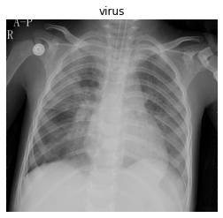

```python
# Ejemplo de cómo se ve una imagen de pulmones con virus
img_virus = view_one_image("/content/COVID_IEEE/","virus")
```

```
['NORMAL2-IM-0874-0001.jpeg']
image shape (1299, 1748)
```

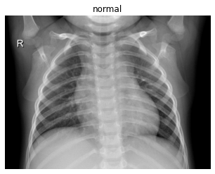

```python
# Ejemplo de cómo se ve una imagen de pulmones sanos
img_normal = view_one_image("/content/COVID_IEEE/","normal")
```

```
['1.CXRCTThoraximagesofCOVID-19fromSingapore.pdf-001-fig2a.png']
image shape (576, 516, 4)
```

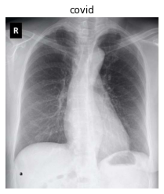

```python
# Ejemplo de cómo se ve una imagen de pulmones con Covid
img_covid = view_one_image("/content/COVID_IEEE/","covid")
```

# **Normalización de datos**

Las redes neuronales reciben entradas del mismo tamaño, redimensiono todas las imágenes a un tamaño fijo antes de ingresarlas a la CNN. A mayor tamaño fijo, menos contracción es requerida. Menos encogimiento significa menos deformación de características y patrones dentro de la imagen.

```python
# Función para extraer la data de cada una de las carpetas
def data_extract():
    data=[]
    labels=[]

    #Covid
    covid=os.listdir("/content/COVID_IEEE/covid/")
    for a in covid:
      image = cv2.imread("/content/COVID_IEEE/covid/"+a,)
      image = cv2.resize(image, (224, 224))
      data.append(image)
      labels.append(0)
    #Normal
    normal=os.listdir("/content/COVID_IEEE/normal/")
    for a in normal:
      image = cv2.imread("/content/COVID_IEEE/normal/"+a,)
      image = cv2.resize(image, (224, 224))
      data.append(image)
      labels.append(1)

    #Virus
    virus=os.listdir("/content/COVID_IEEE/virus/")
    for a in virus:
      image = cv2.imread("/content/COVID_IEEE/virus/"+a,)
      image = cv2.resize(image, (224, 224))
      data.append(image)
      labels.append(2)

    return data, labels
```

```python
# Guardando la data y las etiquetas
data, labels = data_extract()
```

```python
# Convierto a numpy array
data = np.array(data) / 255.0
img_labels = np.array(labels)
```

# **Preparación de particiones para Entrenamiento, Validación y Prueba**

```python
# Particionamiento de los datos.
X_train, X_test, y_train, y_test = train_test_split(data, img_labels, test_size=0.20, random_state=42)
y_train = tf.keras.utils.to_categorical(y_train, num_classes=3)
y_test = tf.keras.utils.to_categorical(y_test, num_classes=3)
```

```python
# Función para mostrar datos
def plot_data(title,data):
    print(title)
    for i in range(9):
    # define subplot
      pyplot.subplot(330 + 1 + i)
    # plot raw pixel data
      pyplot.imshow(X_train[i], cmap=pyplot.get_cmap('binary'))
    # show the figure
    pyplot.show()
```

```
IMAGENES DE ENTRENAMIENTO
```

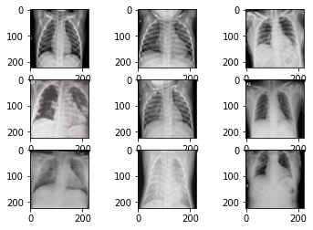

[output not shown]

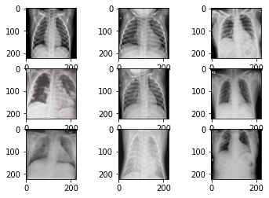

```python
# Datos de entrenamiento
plot_data(title='IMAGENES DE ENTRENAMIENTO',data=X_train)
plot_data(title='IMAGENES DE PRUEBA',data=X_test)
```

```python
# Cantid de datos de entrenamiento y prueba
print(f'Cantidad de datos de Entrenamiento X_train: {len(X_train)}')
print(f'Cantidad de datos de Entrenamiento y_train: {len(y_train)}')
print(f'Cantidad de datos de prueba X_test: {len(X_test)}')
print(f'Cantidad de datos de prueba y_test: {len(y_test)}')
```

```
Cantidad de datos de Entrenamiento X_train: 1458
Cantidad de datos de Entrenamiento y_train: 1458
Cantidad de datos de prueba X_test: 365
Cantidad de datos de prueba y_test: 365
```

```python
# Forma de Entrenamiento
print(f'Shape X_train: {X_train.shape}')
print(f'Shape y_train: {(y_train.shape)}')
print(f'Shape X_test: {(X_test.shape)}')
print(f'Shape y_test: {(y_test.shape)}')
```

```
Shape X_train: (1458, 224, 224, 3)
Shape y_train: (1458, 3)
Shape X_test: (365, 224, 224, 3)
Shape y_test: (365, 3)
```

# **Modelado**

Crearé distintos modelos el siguiente siempre basado en el anterior, con el fin de mejorar la presición y eficiencia al máximo

## **Modelo 1 - Shallow**

Luego de probar distintas arquitecturas, seleccioné esta que me dió el mejor accurracy. No incluyo el resto para no llenar excesivamente el documento, sino que parto de esta para la mejora de presición y eficiencia con los siguientes modelos.

Comentaré a detalle este modelo ya que es la base de los siguientes, y para los siguientes sólo comentaré la mejora que corresponda.

### **Creación**

```python
def construct_model():
  model = Sequential()

  #Block Number 1
  model.add(Conv2D(input_shape = (224,224,3), filters=32,padding="same", kernel_size= (3,3)))
  model.add(Activation("relu"))
  model.add(Conv2D(filters=32,padding="same", kernel_size= (3,3)))
  model.add(Activation("relu"))
  model.add(MaxPool2D((2,2)))

  #Block Number 2
  model.add(Conv2D(filters=64,padding="same", kernel_size= (3,3)))
  model.add(Activation("relu"))
  model.add(Conv2D(filters=64,padding="same", kernel_size= (3,3)))
  model.add(Activation("relu"))
  model.add(MaxPool2D((2,2)))

  #Block Number 3
  model.add(Conv2D(filters=128,padding="same", kernel_size= (3,3)))
  model.add(Activation("relu"))
  model.add(Conv2D(filters=128,padding="same", kernel_size= (3,3)))
  model.add(Activation("relu"))
  model.add(MaxPool2D((2,2)))
  model.add(MaxPool2D((2,2)))

  # Fully Connected layer
  model.add(Flatten()) #Capa flattening para convertir las capas en vectores - Transforma un tensor n-dimensional en un vector que se puede alimentar la capa Fully Connected.
  model.add(Dense(units=1024, activation="relu"))
  model.add(Dense(units=256, activation="relu"))
  # Output Layer
  model.add(Dense(units=3, activation="softmax")) #Un output layer con 3 neuronas corr a las 3 clases (Covid, Virus y Sano) y una activación softmax

  model.compile(optimizer='adam',loss='categorical_crossentropy',metrics=['accuracy'])
  return model
```

Softmax -> Funcio de activación para resolver problemas de clasificación Relu -> La función de activación activa los pesos de una neurona según el resultado de dicha neurona en el mundo de la inteligencia artificial.

### **Visualización**

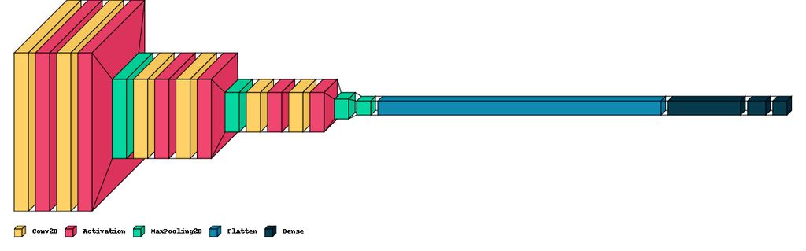

```python
#Visualización del modelo en capas
model=construct_model()
visualkeras.layered_view(model, legend=True,scale_xy=1,padding= 20 )
```

```python
ann_viz(model, view=True,filename="cconstruct_model.gv", title="CNN — Modelo 1", )
```

```python
with open("cconstruct_model.gv") as f:
    dot_graph = f.read()

graphviz.Source(dot_graph, format = "png")
```

[output not shown]

```python
# Resumeno Modelo Shallow
model.summary()
```

```
Model: "sequential"
_________________________________________________________________
 Layer (type)                Output Shape              Param #
=================================================================
 conv2d (Conv2D)             (None, 224, 224, 32)      896

 activation (Activation)     (None, 224, 224, 32)      0

 conv2d_1 (Conv2D)           (None, 224, 224, 32)      9248

 activation_1 (Activation)   (None, 224, 224, 32)      0

 max_pooling2d (MaxPooling2D  (None, 112, 112, 32)     0
 )

 conv2d_2 (Conv2D)           (None, 112, 112, 64)      18496

 activation_2 (Activation)   (None, 112, 112, 64)      0

 conv2d_3 (Conv2D)           (None, 112, 112, 64)      36928

 activation_3 (Activation)   (None, 112, 112, 64)      0

 max_pooling2d_1 (MaxPooling  (None, 56, 56, 64)       0
 2D)

 conv2d_4 (Conv2D)           (None, 56, 56, 128)       73856

 activation_4 (Activation)   (None, 56, 56, 128)       0

 conv2d_5 (Conv2D)           (None, 56, 56, 128)       147584

 activation_5 (Activation)   (None, 56, 56, 128)       0

 max_pooling2d_2 (MaxPooling  (None, 28, 28, 128)      0
 2D)

 max_pooling2d_3 (MaxPooling  (None, 14, 14, 128)      0
 2D)

 flatten (Flatten)           (None, 25088)             0

 dense (Dense)               (None, 1024)              25691136

 dense_1 (Dense)             (None, 256)               262400

 dense_2 (Dense)             (None, 3)                 771

=================================================================
Total params: 26,241,315
Trainable params: 26,241,315
Non-trainable params: 0
_________________________________________________________________
```

### **Entrenamiento**

```python
# Fit Shallow
start = time.time()
model.fit(X_train, y_train, validation_split=0.3, epochs=15, batch_size=32)
tiempo_shallow = time.time() - start
print(tiempo_shallow,'Segundos')
```

```
28.45876145362854 Segundos
```

### **Validación**

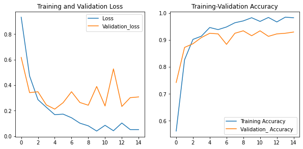

```python
#saving the model history
loss = pd.DataFrame(model.history.history)

#plotting the loss and accuracy
plt.figure(figsize=(10,10))

plt.subplot(2,2,1)
plt.plot(loss["loss"], label ="Loss")
plt.plot(loss["val_loss"], label = "Validation_loss")
plt.legend()
plt.title("Training and Validation Loss")

plt.subplot(2,2,2)
plt.plot(loss['accuracy'],label = "Training Accuracy")
plt.plot(loss['val_accuracy'], label ="Validation_ Accuracy ")
plt.legend()
plt.title("Training-Validation Accuracy")
```

### **Predicciones**

```python
# Predicciones
predictions = model.predict(X_test)
y_pred = np.argmax(predictions, axis = 1)
y_test_new = np.argmax(y_test, axis = 1)
```

### **Evaluación**

```python
# Evaluación del Modelo
print(classification_report(y_test_new, y_pred))
```

```
              precision    recall  f1-score   support

           0       0.94      0.95      0.95       108
           1       0.97      0.90      0.93       129
           2       0.88      0.93      0.90       128

    accuracy                           0.93       365
   macro avg       0.93      0.93      0.93       365
weighted avg       0.93      0.93      0.93       365
```

```python
pd.DataFrame(confusion_matrix(y_test_new, y_pred), columns= ["covid", "normal", "virus"], index = ["covid", "normal", "virus"])
```

|  | covid | normal | virus |
| --- | --- | --- | --- |
| covid | 103 | 1 | 4 |
| normal | 0 | 116 | 13 |
| virus | 6 | 3 | 119 |

```python
print(f'Modelo estructura Shallow {accuracy_score(y_test_new,y_pred)*100}')
```

```
Modelo estructura Shallow 92.6027397260274
```

## **Modelo 2 - Deep Artificial Neural Network**

### **Creación**

```python
def deep_model():
  model = Sequential()

  #Block Number 1
  model.add(Conv2D(input_shape = (224,224,3), filters=32,padding="same", kernel_size= (3,3)))
  model.add(Activation("relu"))
  model.add(Conv2D(filters=32,padding="same", kernel_size= (3,3)))
  model.add(Activation("relu"))
  model.add(MaxPool2D((2,2)))

  #Block Number 2
  model.add(Conv2D(filters=64,padding="same", kernel_size= (3,3)))
  model.add(Activation("relu"))
  model.add(Conv2D(filters=64,padding="same", kernel_size= (3,3)))
  model.add(Activation("relu"))
  model.add(MaxPool2D((2,2)))

  #Block Number 3
  model.add(Conv2D(filters=128,padding="same", kernel_size= (3,3)))
  model.add(Activation("relu"))
  model.add(Conv2D(filters=128,padding="same", kernel_size= (3,3)))
  model.add(Activation("relu"))
  model.add(MaxPool2D((2,2)))
  model.add(MaxPool2D((2,2)))


  # Fully Connected layer
  model.add(Flatten())
  model.add(Dense(units=1024, activation="relu"))
  model.add(Dense(units=256, activation="relu"))
  model.add(Dense(units=128, activation="relu"))
  # Output Layer
  model.add(Dense(units=3, activation="softmax")) #Un output layer con 3 neuronas corr a las 3 clases (Covid, Virus y Sano) y una activación softmax

  model.compile(optimizer='adam',loss='categorical_crossentropy',metrics=['accuracy'])
  return model
```

### **Visualización**

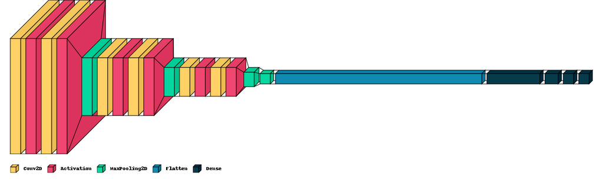

```python
#Visualización del modelo en capas
deep_model = deep_model()
visualkeras.layered_view(deep_model, legend=True,scale_xy=1,padding= 20 )
```

```python
ann_viz(deep_model, view=True,filename="cconstruct_model2.gv", title="CNN — Modelo 2", )
```

```python
# Resumen de la Arquitectura de las redes
deep_model.summary()
```

```
Model: "sequential_1"
_________________________________________________________________
 Layer (type)                Output Shape              Param #
=================================================================
 conv2d_6 (Conv2D)           (None, 224, 224, 32)      896

 activation_6 (Activation)   (None, 224, 224, 32)      0

 conv2d_7 (Conv2D)           (None, 224, 224, 32)      9248

 activation_7 (Activation)   (None, 224, 224, 32)      0

 max_pooling2d_4 (MaxPooling  (None, 112, 112, 32)     0
 2D)

 conv2d_8 (Conv2D)           (None, 112, 112, 64)      18496

 activation_8 (Activation)   (None, 112, 112, 64)      0

 conv2d_9 (Conv2D)           (None, 112, 112, 64)      36928

 activation_9 (Activation)   (None, 112, 112, 64)      0

 max_pooling2d_5 (MaxPooling  (None, 56, 56, 64)       0
 2D)

 conv2d_10 (Conv2D)          (None, 56, 56, 128)       73856

 activation_10 (Activation)  (None, 56, 56, 128)       0

 conv2d_11 (Conv2D)          (None, 56, 56, 128)       147584

 activation_11 (Activation)  (None, 56, 56, 128)       0

 max_pooling2d_6 (MaxPooling  (None, 28, 28, 128)      0
 2D)

 max_pooling2d_7 (MaxPooling  (None, 14, 14, 128)      0
 2D)

 flatten_1 (Flatten)         (None, 25088)             0

 dense_3 (Dense)             (None, 1024)              25691136

 dense_4 (Dense)             (None, 256)               262400

 dense_5 (Dense)             (None, 128)               32896

 dense_6 (Dense)             (None, 3)                 387

=================================================================
Total params: 26,273,827
Trainable params: 26,273,827
Non-trainable params: 0
_________________________________________________________________
```

### **Entrenamiento**

```python
# Fit Deep Model
start = time.time()
deep_model.fit(X_train, y_train, validation_split=0.3, epochs=15, batch_size=32)
tiempo_deep = time.time() - start
print(tiempo_deep,'Segundos')
```

```
17.960986614227295 Segundos
```

### **Validación**

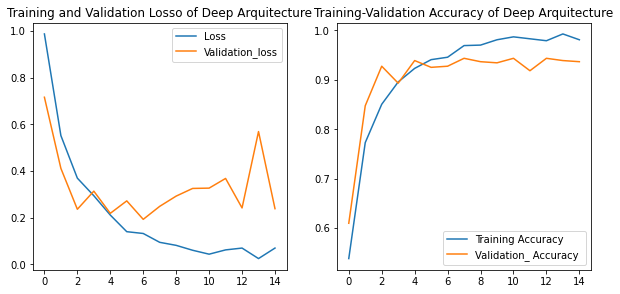

```python
#saving the model history
deep_loss = pd.DataFrame(deep_model.history.history)

#plotting the loss and accuracy
plt.figure(figsize=(10,10))

plt.subplot(2,2,1)
plt.plot(deep_loss["loss"], label ="Loss")
plt.plot(deep_loss["val_loss"], label = "Validation_loss")
plt.legend()
plt.title("Training and Validation Losso of Deep Arquitecture")

plt.subplot(2,2,2)
plt.plot(deep_loss['accuracy'],label = "Training Accuracy")
plt.plot(deep_loss['val_accuracy'], label ="Validation_ Accuracy ")
plt.legend()
plt.title("Training-Validation Accuracy of Deep Arquitecture")
```

### **Predicciones**

```python
# Predicciones
deep_predictions = deep_model.predict(X_test)
y_pred_deep = np.argmax(deep_predictions, axis = 1)
y_test_deep = np.argmax(y_test, axis = 1)
```

### **Evaluación**

```python
# Matriz de Confusión de El modelo con arquitectura Deep
pd.DataFrame(confusion_matrix(y_test_deep, y_pred_deep), columns= ["covid", "normal", "virus"], index = ["covid", "normal", "virus"])
```

|  | covid | normal | virus |
| --- | --- | --- | --- |
| covid | 105 | 1 | 2 |
| normal | 1 | 124 | 4 |
| virus | 6 | 9 | 113 |

```python
print(f'Modelo estructura deep {accuracy_score(y_test_deep,y_pred_deep)*100}')
```

```
Modelo estructura deep 93.69863013698631
```

## **Modelo 3 - Data Augmentation**

### **Creación**

```python
# Crear variaciones de las imagenes horizontales y vertifcales
data_augmentation = keras.Sequential([
  layers.RandomFlip("horizontal_and_vertical"),
  layers.RandomRotation(0.4),
])
```

```python
def augmentation_model():
  model = Sequential()
  # Adding Data Augmentation
  data_augmentation

  #Block Number 1
  model.add(Conv2D(input_shape = (224,224,3), filters=32,padding="same", kernel_size= (3,3)))
  model.add(Activation("relu"))
  model.add(Conv2D(filters=32,padding="same", kernel_size= (3,3)))
  model.add(Activation("relu"))
  model.add(MaxPool2D((2,2)))

  #Block Number 2
  model.add(Conv2D(filters=64,padding="same", kernel_size= (3,3)))
  model.add(Activation("relu"))
  model.add(Conv2D(filters=64,padding="same", kernel_size= (3,3)))
  model.add(Activation("relu"))
  model.add(MaxPool2D((2,2)))

  #Block Number 3
  model.add(Conv2D(filters=128,padding="same", kernel_size= (3,3)))
  model.add(Activation("relu"))
  model.add(Conv2D(filters=128,padding="same", kernel_size= (3,3)))
  model.add(Activation("relu"))
  model.add(MaxPool2D((2,2)))
  model.add(MaxPool2D((2,2)))

  # Fully Connected layer
  model.add(Flatten())
  model.add(Dense(units=1024, activation="relu"))
  model.add(Dense(units=256, activation="relu"))
  model.add(Dense(units=128, activation="relu"))
  # Output Layer
  model.add(Dense(units=3, activation="softmax"))

  model.compile(optimizer='adam',loss='categorical_crossentropy',metrics=['accuracy'])
  return model
```

### **Visualización**

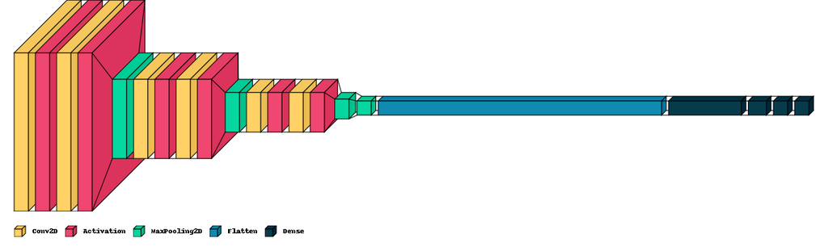

```python
#Visualización del modelo en capas
augmentation_model = augmentation_model()
visualkeras.layered_view(augmentation_model, legend=True,scale_xy=1,padding= 20 )
```

```python
# Resumen de la Arquitectura de las redes
augmentation_model.summary()
```

```
Model: "sequential_7"
_________________________________________________________________
 Layer (type)                Output Shape              Param #
=================================================================
 conv2d_24 (Conv2D)          (None, 224, 224, 32)      896

 activation_24 (Activation)  (None, 224, 224, 32)      0

 conv2d_25 (Conv2D)          (None, 224, 224, 32)      9248

 activation_25 (Activation)  (None, 224, 224, 32)      0

 max_pooling2d_16 (MaxPoolin  (None, 112, 112, 32)     0
 g2D)

 conv2d_26 (Conv2D)          (None, 112, 112, 64)      18496

 activation_26 (Activation)  (None, 112, 112, 64)      0

 conv2d_27 (Conv2D)          (None, 112, 112, 64)      36928

 activation_27 (Activation)  (None, 112, 112, 64)      0

 max_pooling2d_17 (MaxPoolin  (None, 56, 56, 64)       0
 g2D)

 conv2d_28 (Conv2D)          (None, 56, 56, 128)       73856

 activation_28 (Activation)  (None, 56, 56, 128)       0

 conv2d_29 (Conv2D)          (None, 56, 56, 128)       147584

 activation_29 (Activation)  (None, 56, 56, 128)       0

 max_pooling2d_18 (MaxPoolin  (None, 28, 28, 128)      0
 g2D)

 max_pooling2d_19 (MaxPoolin  (None, 14, 14, 128)      0
 g2D)

 flatten_5 (Flatten)         (None, 25088)             0

 dense_19 (Dense)            (None, 1024)              25691136

 dense_20 (Dense)            (None, 256)               262400

 dense_21 (Dense)            (None, 128)               32896

 dense_22 (Dense)            (None, 3)                 387

=================================================================
Total params: 26,273,827
Trainable params: 26,273,827
Non-trainable params: 0
_________________________________________________________________
```

### **Entrenamiento**

```python
# Fit Aug
start = time.time()
augmentation_model.fit(X_train, y_train, validation_split=0.3, epochs=15, batch_size=32)
tiempo_aug = time.time() - start
print(tiempo_aug,'Segundos')
```

```
17.562697887420654 Segundos
```

### **Validación**

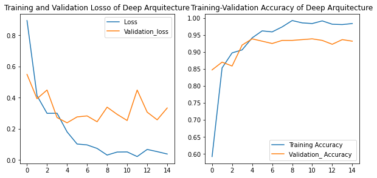

```python
#saving the model history
augmentation_loss = pd.DataFrame(augmentation_model.history.history)

#plotting the loss and accuracy
plt.figure(figsize=(10,10))

plt.subplot(2,2,1)
plt.plot(augmentation_loss["loss"], label ="Loss")
plt.plot(augmentation_loss["val_loss"], label = "Validation_loss")
plt.legend()
plt.title("Training and Validation Losso of Deep Arquitecture")

plt.subplot(2,2,2)
plt.plot(augmentation_loss['accuracy'],label = "Training Accuracy")
plt.plot(augmentation_loss['val_accuracy'], label ="Validation_ Accuracy ")
plt.legend()
plt.title("Training-Validation Accuracy of Deep Arquitecture")
```

### **Predicciones**

```python
# Predicciones
augmentation_predictions = augmentation_model.predict(X_test)
y_pred_aug = np.argmax(augmentation_predictions, axis = 1)
y_test_aug = np.argmax(y_test, axis = 1)
```

### **Evaluación**

```python
# Matriz de Confusión de El modelo con arquitectura Deep
pd.DataFrame(confusion_matrix(y_test_aug, y_pred_aug), columns= ["covid", "normal", "virus"], index = ["covid", "normal", "virus"])
```

|  | covid | normal | virus |
| --- | --- | --- | --- |
| covid | 104 | 1 | 3 |
| normal | 0 | 129 | 0 |
| virus | 5 | 12 | 111 |

```python
print(f'Modelo de Data Augmentation {accuracy_score(y_test_aug,y_pred_aug)*100}')
```

```
Modelo de Data Augmentation 94.24657534246576
```

## **Modelo 4 - Epochs Optimization**

Los gráficos de pérdida y presición del modelo anterior muestran que a partir de la octava iteración la mejora del modelo no era significativa, por lo que creo otro modelo disminuyendo las épocas a 8, logrando así una mejora en el tiempo de entrenamiento del modelo.

### **Creación**

```python
# Crear variaciones de las imagenes horizontales y vertifcales
data_augmentation = keras.Sequential([
  layers.RandomFlip("horizontal_and_vertical"),
  layers.RandomRotation(0.4),
])
```

```python
def epoch_model():
  model = Sequential()
  # Adding Data Augmentation
  data_augmentation

  #Block Number 1
  model.add(Conv2D(input_shape = (224,224,3), filters=32,padding="same", kernel_size= (3,3)))
  model.add(Activation("relu"))
  model.add(Conv2D(filters=32,padding="same", kernel_size= (3,3)))
  model.add(Activation("relu"))
  model.add(MaxPool2D((2,2)))

  #Block Number 2
  model.add(Conv2D(filters=64,padding="same", kernel_size= (3,3)))
  model.add(Activation("relu"))
  model.add(Conv2D(filters=64,padding="same", kernel_size= (3,3)))
  model.add(Activation("relu"))
  model.add(MaxPool2D((2,2)))

  #Block Number 3
  model.add(Conv2D(filters=128,padding="same", kernel_size= (3,3)))
  model.add(Activation("relu"))
  model.add(Conv2D(filters=128,padding="same", kernel_size= (3,3)))
  model.add(Activation("relu"))
  model.add(MaxPool2D((2,2)))
  model.add(MaxPool2D((2,2)))

  # Fully Connected layer
  model.add(Flatten())
  model.add(Dense(units=1024, activation="relu"))
  model.add(Dense(units=256, activation="relu"))
  model.add(Dense(units=128, activation="relu"))
  # Output Layer
  model.add(Dense(units=3, activation="softmax")) #Un output layer con 3 neuronas corr a las 3 clases (Covid, Virus y Sano) y una activación softmax

  model.compile(optimizer='adam',loss='categorical_crossentropy',metrics=['accuracy'])
  return model
```

```python
# Reutilizando el modelo de data augmentation
epoch_model = epoch_model()
```

### **Visualización**

```python
# Resumen
epoch_model.summary()
```

```
Model: "sequential_9"
_________________________________________________________________
 Layer (type)                Output Shape              Param #
=================================================================
 conv2d_30 (Conv2D)          (None, 224, 224, 32)      896

 activation_30 (Activation)  (None, 224, 224, 32)      0

 conv2d_31 (Conv2D)          (None, 224, 224, 32)      9248

 activation_31 (Activation)  (None, 224, 224, 32)      0

 max_pooling2d_20 (MaxPoolin  (None, 112, 112, 32)     0
 g2D)

 conv2d_32 (Conv2D)          (None, 112, 112, 64)      18496

 activation_32 (Activation)  (None, 112, 112, 64)      0

 conv2d_33 (Conv2D)          (None, 112, 112, 64)      36928

 activation_33 (Activation)  (None, 112, 112, 64)      0

 max_pooling2d_21 (MaxPoolin  (None, 56, 56, 64)       0
 g2D)

 conv2d_34 (Conv2D)          (None, 56, 56, 128)       73856

 activation_34 (Activation)  (None, 56, 56, 128)       0

 conv2d_35 (Conv2D)          (None, 56, 56, 128)       147584

 activation_35 (Activation)  (None, 56, 56, 128)       0

 max_pooling2d_22 (MaxPoolin  (None, 28, 28, 128)      0
 g2D)

 max_pooling2d_23 (MaxPoolin  (None, 14, 14, 128)      0
 g2D)

 flatten_6 (Flatten)         (None, 25088)             0

 dense_23 (Dense)            (None, 1024)              25691136

 dense_24 (Dense)            (None, 256)               262400

 dense_25 (Dense)            (None, 128)               32896

 dense_26 (Dense)            (None, 3)                 387

=================================================================
Total params: 26,273,827
Trainable params: 26,273,827
Non-trainable params: 0
_________________________________________________________________
```

### **Entrenamiento**

```python
# Fit less epoch Model
start = time.time()
epoch_model.fit(X_train, y_train, validation_split=0.3, epochs=8, batch_size=32)
tiempo_epoch = time.time() - start
print(tiempo_epoch,'Segundos')
```

```
11.994091749191284 Segundos
```

### **Validación**

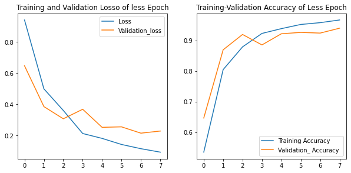

```python
#saving the model history
epoch_loss = pd.DataFrame(epoch_model.history.history)

#plotting the loss and accuracy
plt.figure(figsize=(10,10))

plt.subplot(2,2,1)
plt.plot(epoch_loss["loss"], label ="Loss")
plt.plot(epoch_loss["val_loss"], label = "Validation_loss")
plt.legend()
plt.title("Training and Validation Losso of less Epoch")

plt.subplot(2,2,2)
plt.plot(epoch_loss['accuracy'],label = "Training Accuracy")
plt.plot(epoch_loss['val_accuracy'], label ="Validation_ Accuracy ")
plt.legend()
plt.title("Training-Validation Accuracy of Less Epoch")
```

### **Predicciones**

```python
# Predicciones
epoch_predictions = epoch_model.predict(X_test)
y_pred_epoch = np.argmax(augmentation_predictions, axis = 1)
y_test_epoch = np.argmax(y_test, axis = 1)
```

### **Evaluación**

```python
# Matriz de Confusión de El modelo con arquitectura Deep
pd.DataFrame(confusion_matrix(y_test_epoch, y_pred_epoch), columns= ["covid", "normal", "virus"], index = ["covid", "normal", "virus"])
```

|  | covid | normal | virus |
| --- | --- | --- | --- |
| covid | 104 | 1 | 3 |
| normal | 0 | 129 | 0 |
| virus | 5 | 12 | 111 |

```python
print(f'Modelo de Data Augmentation con menos Iteraciones {accuracy_score(y_test_epoch,y_pred_epoch)*100}')
```

[output not shown]

```python
#if os.path.isfile('models/medical_trial_model.h5') is False:
#model.save('models/deep_model.h5')
```

## **Modelo 5 - Baseline Model - Transfer Learning**

Obtengo un modelo ya pre-entrenado para compararlo con mi modelo. Aunque entregue mejor precisión me quedaré con el que yo diseñé para la productivización

### **Invocación del Modelo**

```python
# Baseline
def base_model():
  base_model = tf.keras.applications.MobileNet(input_shape=[224,224,3], weights = "imagenet", include_top=False) # Obtengo el modelo de MobileNet y desactivo la última capa

  for layer in base_model.layers:
    layer.trainable =False # Congelo los pesos para que no se pueda entrenar
  # Imagenet
  baseline_model = Flatten()(base_model.output)
  baseline_model = Dense(units=1024, activation="relu")(baseline_model)
  baseline_model = Dense(units=512, activation="relu")(baseline_model)
  baseline_model = Dense(units=256, activation="relu")(baseline_model)
  prediction_layer = Dense(units=3, activation="softmax")(baseline_model)
  baseline_model = Model(inputs = base_model.input, outputs = prediction_layer)
  baseline_model.compile(optimizer='adam',loss='categorical_crossentropy',metrics=['accuracy'])
  return baseline_model
```

```python
baseline_model = base_model()
```

```
Downloading data from https://storage.googleapis.com/tensorflow/keras-applications/mobilenet/mobilenet_1_0_224_tf_no_top.h5
```

### **Visualización**

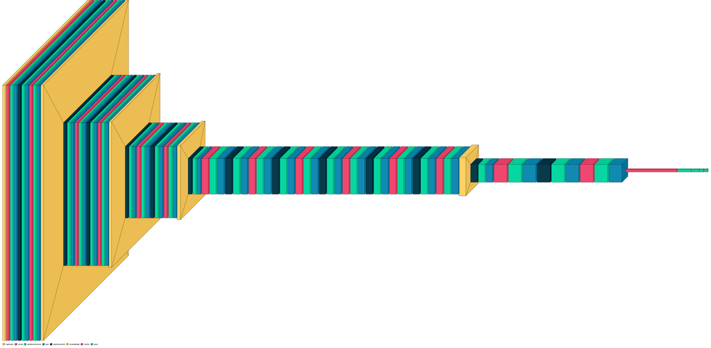

```python
visualkeras.layered_view(baseline_model, legend=True,scale_xy=20,padding= 20 )
```

```python
# Modelo Baseline
baseline_model.summary()
```

```
Model: "model"
_________________________________________________________________
 Layer (type)                Output Shape              Param #
=================================================================
 input_1 (InputLayer)        [(None, 224, 224, 3)]     0

 conv1 (Conv2D)              (None, 112, 112, 32)      864

 conv1_bn (BatchNormalizatio  (None, 112, 112, 32)     128
 n)

 conv1_relu (ReLU)           (None, 112, 112, 32)      0

 conv_dw_1 (DepthwiseConv2D)  (None, 112, 112, 32)     288

 conv_dw_1_bn (BatchNormaliz  (None, 112, 112, 32)     128
 ation)

 conv_dw_1_relu (ReLU)       (None, 112, 112, 32)      0

 conv_pw_1 (Conv2D)          (None, 112, 112, 64)      2048

 conv_pw_1_bn (BatchNormaliz  (None, 112, 112, 64)     256
 ation)

 conv_pw_1_relu (ReLU)       (None, 112, 112, 64)      0

 conv_pad_2 (ZeroPadding2D)  (None, 113, 113, 64)      0

 conv_dw_2 (DepthwiseConv2D)  (None, 56, 56, 64)       576

 conv_dw_2_bn (BatchNormaliz  (None, 56, 56, 64)       256
 ation)

 conv_dw_2_relu (ReLU)       (None, 56, 56, 64)        0

 conv_pw_2 (Conv2D)          (None, 56, 56, 128)       8192

 conv_pw_2_bn (BatchNormaliz  (None, 56, 56, 128)      512
 ation)
```

[output cut: 167 more lines]

```
 flatten_4 (Flatten)         (None, 50176)             0

 dense_15 (Dense)            (None, 1024)              51381248

 dense_16 (Dense)            (None, 512)               524800

 dense_17 (Dense)            (None, 256)               131328

 dense_18 (Dense)            (None, 3)                 771

=================================================================
Total params: 55,267,011
Trainable params: 52,038,147
Non-trainable params: 3,228,864
_________________________________________________________________
```

### **Entrenamiento**

```python
# Entrenamiento base model
start = time.time()
baseline_model.fit(X_train, y_train, validation_split=0.3, epochs=15, batch_size=32)
tiempo_base = time.time() - start
print(tiempo_base,'Segundos')
```

```
14.269365549087524 Segundos
```

### **Validación**

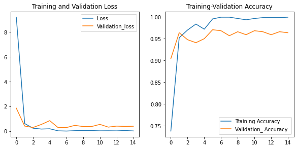

```python
#saving the model history
baseline_loss = pd.DataFrame(baseline_model.history.history)

#plotting the loss and accuracy
plt.figure(figsize=(10,10))

plt.subplot(2,2,1)
plt.plot(baseline_loss["loss"], label ="Loss")
plt.plot(baseline_loss["val_loss"], label = "Validation_loss")
plt.legend()
plt.title("Training and Validation Loss")

plt.subplot(2,2,2)
plt.plot(baseline_loss['accuracy'],label = "Training Accuracy")
plt.plot(baseline_loss['val_accuracy'], label ="Validation_ Accuracy ")
plt.legend()
plt.title("Training-Validation Accuracy")
```

### **Prediccion**

```python
# Prediccciones
base_predictions = baseline_model.predict(X_test)

y_pred_base = np.argmax(base_predictions, axis = 1)
y_test_base = np.argmax(y_test, axis = 1)
```

### **Evaluación**

```python
print(classification_report(y_test_base, y_pred_base))
```

```
              precision    recall  f1-score   support

           0       1.00      1.00      1.00       108
           1       0.95      0.98      0.97       129
           2       0.98      0.95      0.96       128

    accuracy                           0.98       365
   macro avg       0.98      0.98      0.98       365
weighted avg       0.98      0.98      0.98       365
```

```python
# Matriz de Confusión de El modelo con arquitectura Deep
pd.DataFrame(confusion_matrix(y_test_base, y_pred_base), columns= ["covid", "normal", "virus"], index = ["covid", "normal", "virus"])
```

|  | covid | normal | virus |
| --- | --- | --- | --- |
| covid | 108 | 0 | 0 |
| normal | 0 | 126 | 3 |
| virus | 0 | 6 | 122 |

```python
print(f'Modelo Baseline {accuracy_score(y_test_base,y_pred_base)*100} %')
```

```
Modelo Baseline 97.53424657534246 %
```

# **Puntuaciones por modelo**

```python
print(f'Modelo estructura Shallow {accuracy_score(y_test_new,y_pred)*100}%')
print(f'Modelo estructura deep {accuracy_score(y_test_deep,y_pred_deep)*100}%')
print(f'Modelo de Data Augmentation {accuracy_score(y_test_aug,y_pred_aug)*100}%')
print(f'Modelo de Data Augmentation con menos Iteraciones {accuracy_score(y_test_epoch,y_pred_epoch)*100}%')
print(f'Modelo Baseline {accuracy_score(y_test_base,y_pred_base)*100} %')
```

```
Modelo estructura Shallow 92.6027397260274%
Modelo estructura deep 93.69863013698631%
Modelo de Data Augmentation 94.24657534246576%
Modelo de Data Augmentation con menos Iteraciones 94.24657534246576%
Modelo Baseline 97.53424657534246 %
```

# **Tiempos por modelo**

```python
print(f'Modelo estructura Shallow {tiempo_shallow} seg')
print(f'Modelo estructura deep {tiempo_deep} seg')
print(f'Modelo de Data Augmentation {tiempo_aug} seg')
print(f'Modelo de Data Augmentation con menos Iteraciones {tiempo_epoch} seg')
print(f'Modelo Baseline {tiempo_base} seg')
```

```
Modelo estructura Shallow 28.45876145362854 seg
Modelo estructura deep 17.960986614227295 seg
Modelo de Data Augmentation 17.562697887420654 seg
Modelo de Data Augmentation con menos Iteraciones 11.994091749191284 seg
Modelo Baseline 14.269365549087524 seg
```